# Formula 1 2024 Spanish Grand Prix

12-09-24

## Introduction

This data science project concerns the Formula 1 2024 season, focusing in particular on the **Spanish Grand Prix**. The **Spanish Grand Prix** was held across the weekend of 21-23 June 2024 at the **Circuit de Barcelona-Catalunya** in **Montmeló**, Spain. It was the 10th round of the F1 2024 World Championship.

Historically, this Grand Prix is often an important event for the engineering developments of the cars, exploiting the features of the track that are very helpful to understand aerodynamics upgrades. For this reason, this weekend could be a crucial turning point for the remainder part of the season.

The project consists of two parts: the first part shows the background of the **Spanish Grand Prix**, going into the details of the competition results achieved before this event. The second part analyzes the on-track performances of the Spanish race, highlighting the hierarchies of the contenders.

## Datasets

This project uses two distinct datasets:

1. [Formula 1 2024 - Results](https://github.com/toUpperCase78/formula1-datasets)
2. [Formula 1 2024 - Spanish race data](https://www.kaggle.com/datasets/rohanrao/formula-1-world-championship-1950-2020)

The first one contains the data of the final classifications of the previous Grand Prix. The second one contains the performance data of the **Spanish Grand Prix**, storing the lap times of the drivers during the race session.

## Part 1 Overview of the previous results

## Drivers Standings

Let’s show the drivers standings before the **Spanish Grand Prix**

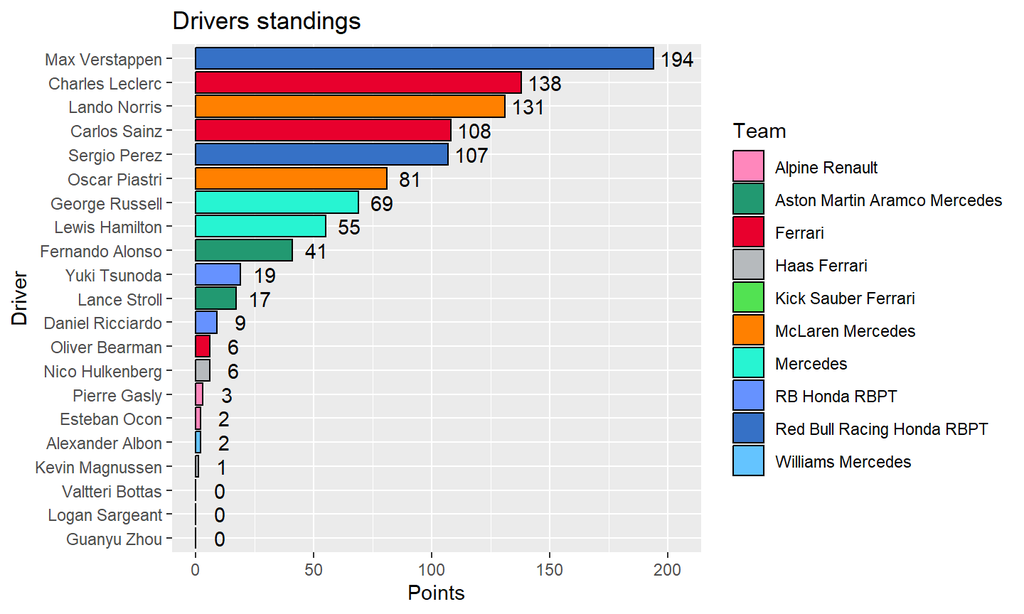

## Constructors Standings

Let’s show the constructors standings before the **Spanish Grand Prix**

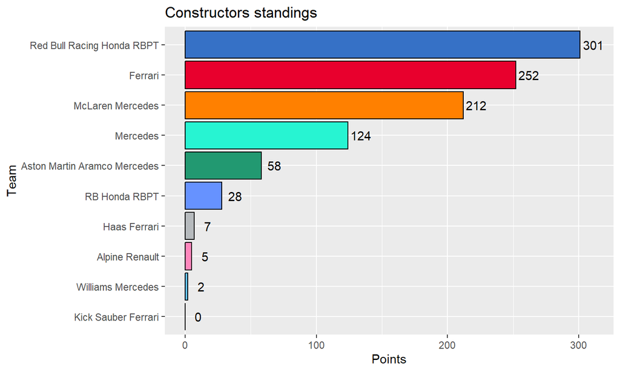

## Performance classes

Using these standings, the drivers are divided into performance classes using hierarchical clustering

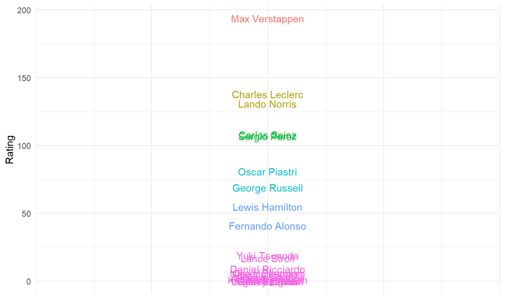

This computation is repeated also for constructors

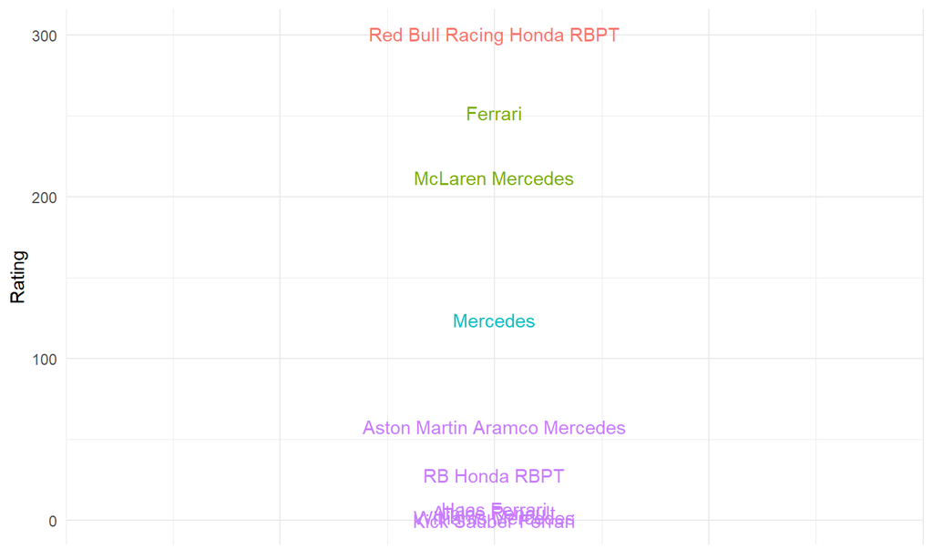

## Title contenders drivers Trend Analysis

The previous plots show the overall results in a fixed point (the situation immediately before the **Spanish Grand Prix**). But it’s also interesting analyze how they changed during the ongoing season

[video not shown]

## Title contenders constructors Trend Analysis

Let’s have a look also to the constructors results

[video not shown]

## Part 2 Spanish Grand Prix performances

## Are qualifying sessions worth to be considered?

There is a correlation between grid position and final race position?

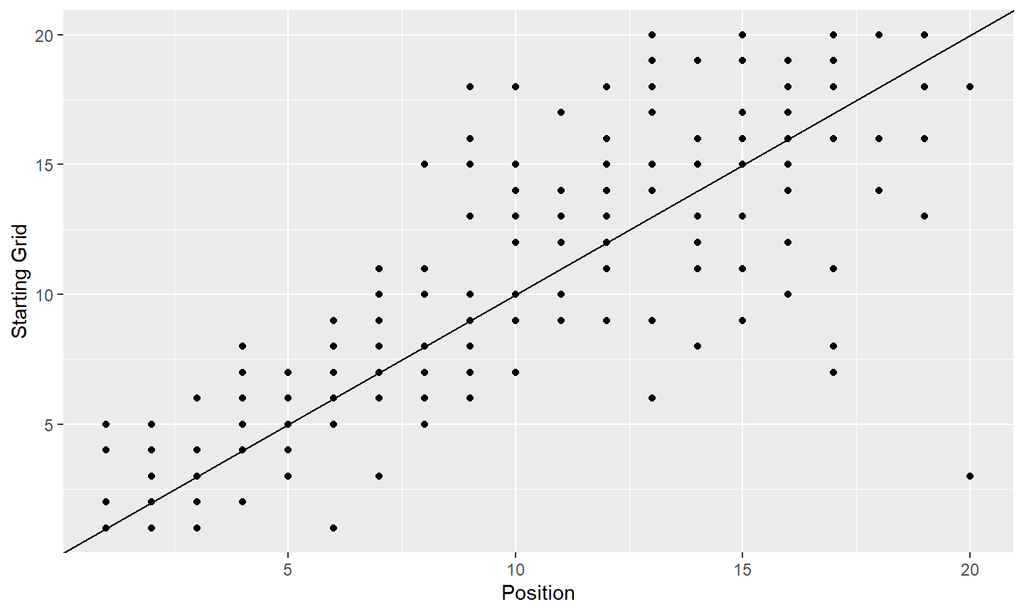

Looks like there is a positive linear correlation between the starting position and the final position. To have a confirmation about that, let’s compute the **Pearson correlation coefficient** \(R\):

- \(R\) = 0.8207741

## Qualifying performances

Performances of the last part of the qualifying session at **Spanish Grand Prix**

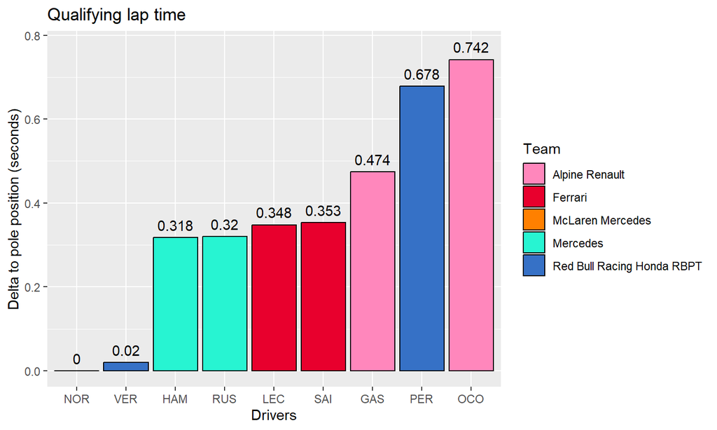

## Race lap times performances

Let’s visualize the lap times registered during the whole race by the title contenders drivers

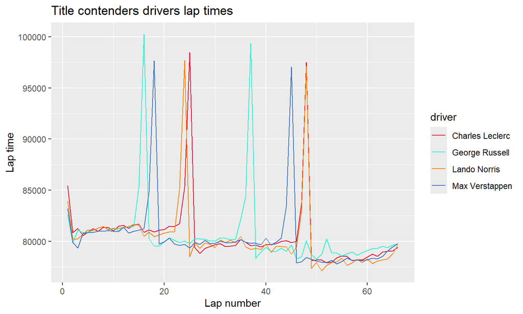

## Race lap times distribution

Let’s have a look also to the distribution of the lap times

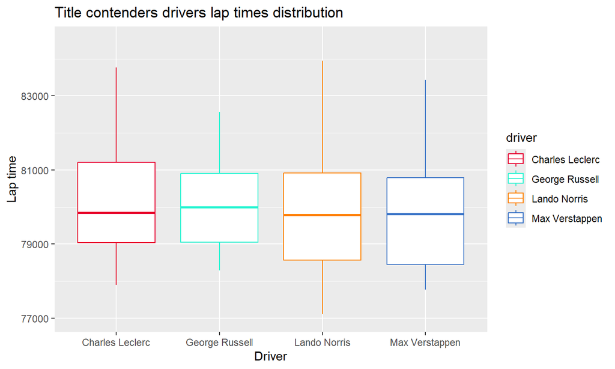

## Race gaps to the race winner

The overall driver performance is obtained computing the final gaps respect to the race winner

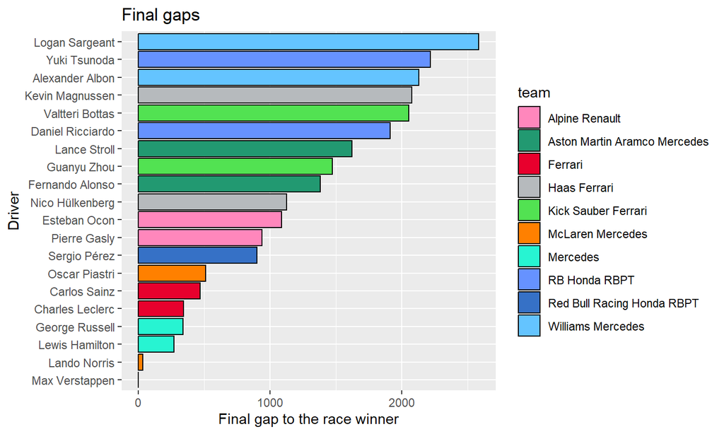

It’s possible to compute the mean between the average lap time of drivers who race for the same team, visualizing the average gaps respect to the fastest average lap times team

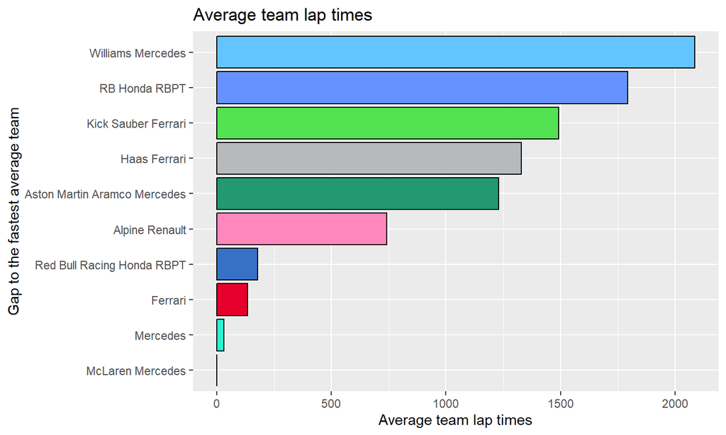

## Spanish Grand Prix performance classes

In conclusion, let’s divide the drivers performances into classes using hierachical clustering

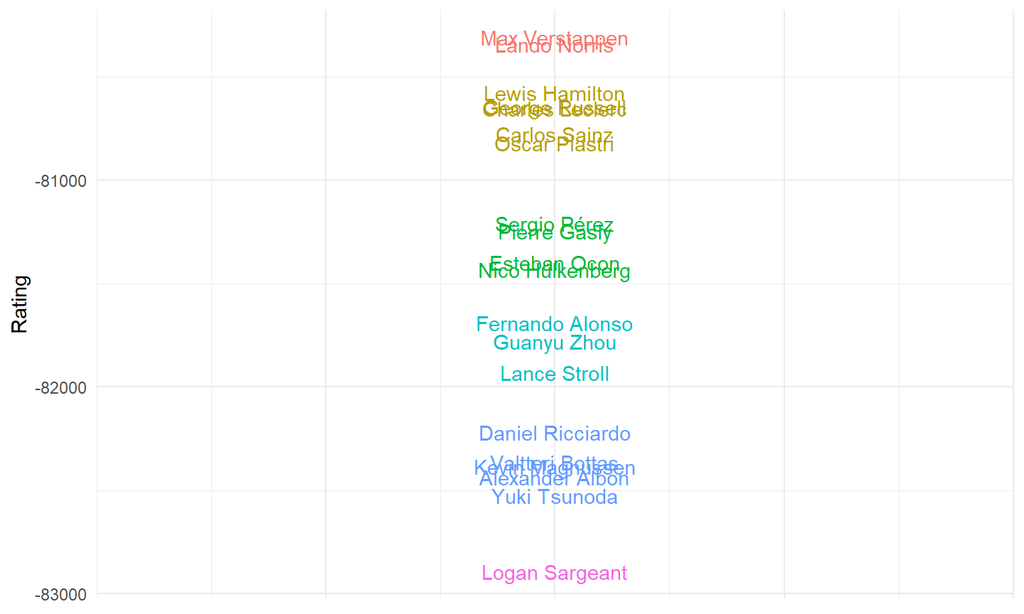

The computation is repeated to divide teams into classes

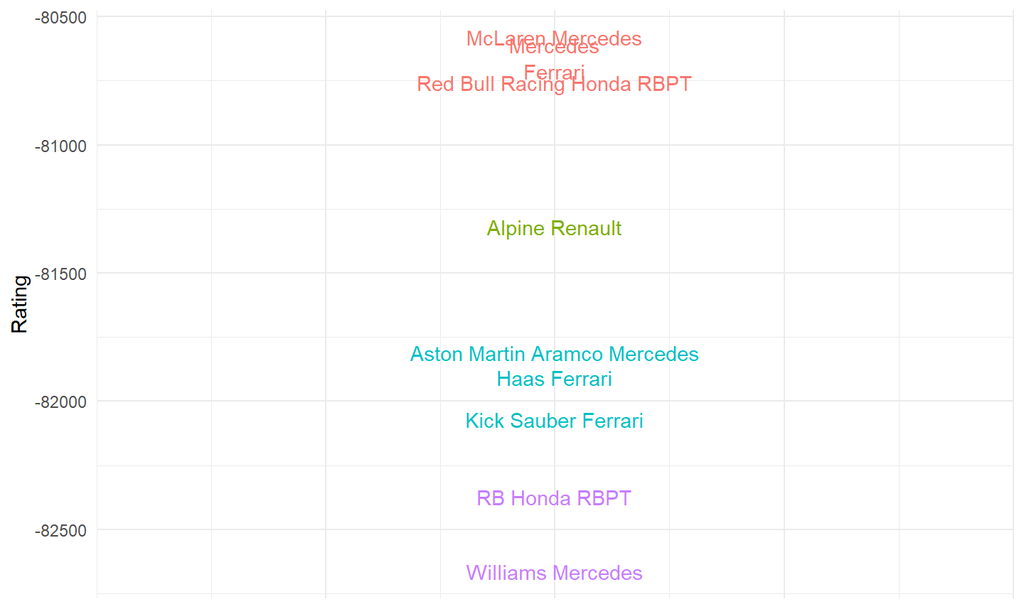